# Homework 1 by Qingcheng Wei

## Excercise 4

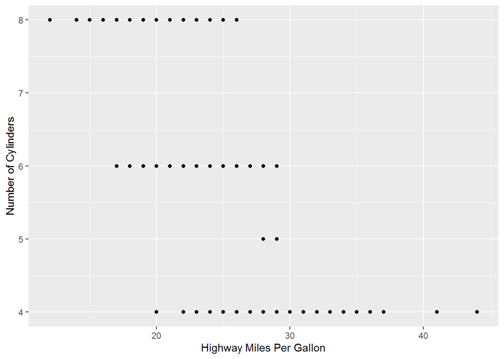

```r
ggplot(data=mpg,aes(x=hwy,y=cyl)) +
  geom_point() +
  xlab("Highway Miles Per Gallon") +
  ylab("Number of Cylinders")
```

## Excercise 5

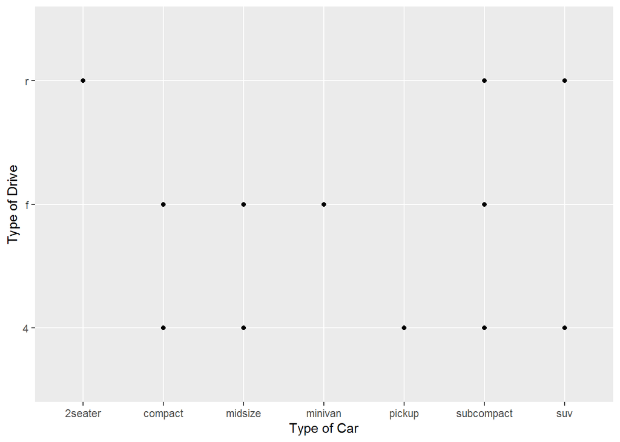

```r
ggplot(data=mpg,aes(x=class,y=drv)) +
  geom_point() +
  xlab("Type of Car") +
  ylab("Type of Drive")
```

Scatter plots are not meant to visualize the relationship between two categorical/qualitative variables.

# Chapter 1 (Pg. 12)

## Exercise 1

The “color= ‘blue’” should be outside the aes braket. since color is not mapping with any variable in mpg data set but manually give a certain value.

## Exercise 2

The categorical variables are: manufactuer, model, year, trans, drv, fl, class.The numerical variables are: hwy, cty, displ, cyl.I can see these information by reading the format and speculate.

## Exercise 5

The stroke aesthetic modifies the width of the border of the points. It works with the shapes with border.

# Chapter 1 (Pgs. 20-21)

## Exercise 1

geom_line()for line chart, geom_boxplot() for boxplot, geom_instagram() for instogram, geom_area() for area chart

## Exercise 2

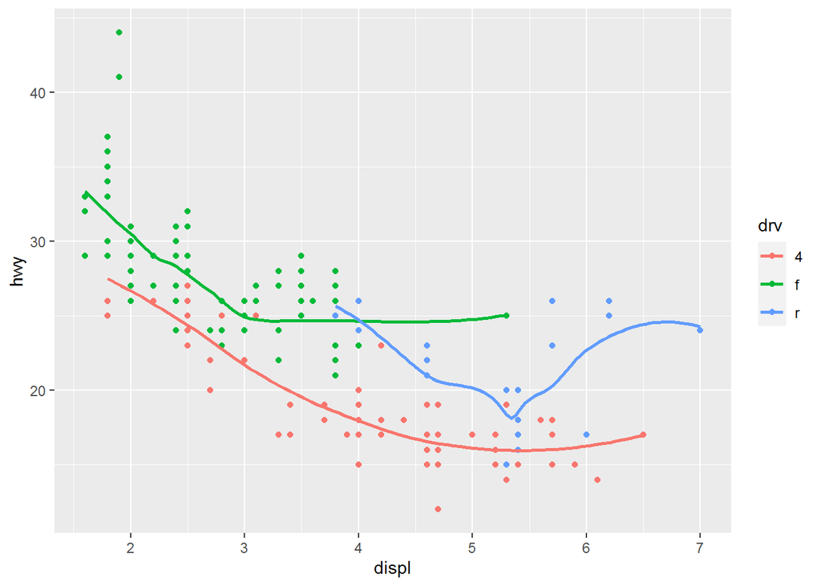

```r
ggplot(
data = mpg,
mapping = aes(x = displ, y = hwy, color = drv)) +
geom_point() +
geom_smooth(se = FALSE)
```

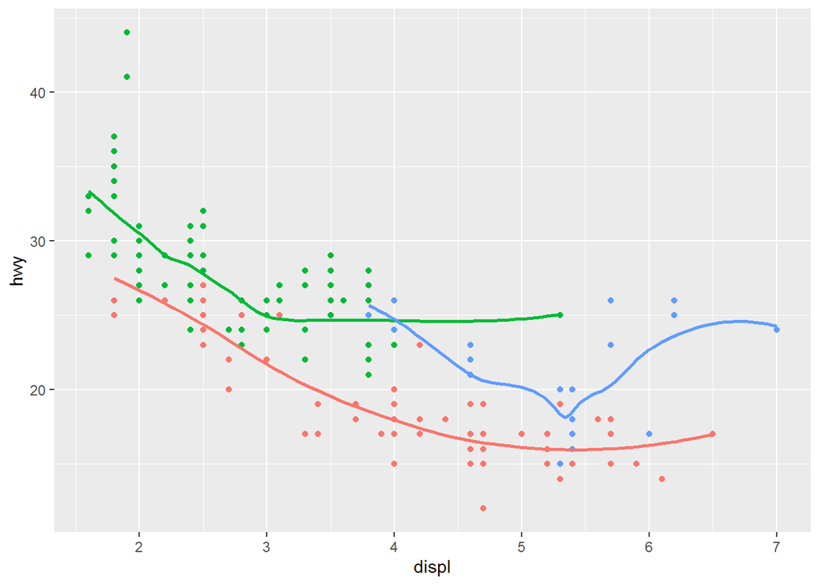

```r
ggplot(
data = mpg,
mapping = aes(x = displ, y = hwy, color = drv)) +
geom_point(show.legend=FALSE) +
geom_smooth(se = FALSE,show.legend=FALSE)
```

It supposes to remove the legend from right hand side. After it remove, it will show the legend telling you each subset corresponds to which color, shape, etc. the author uses it before to make the three charts generated look uniform.

## Exercise 4

It removes the shadow behind the relative lines, and the shadow is actually the confidence band for each line. Se argument actually controls whether to remove it or not to make the graph look tidier.

## Exercise 5

I don’t know if they will look different. Let me check.

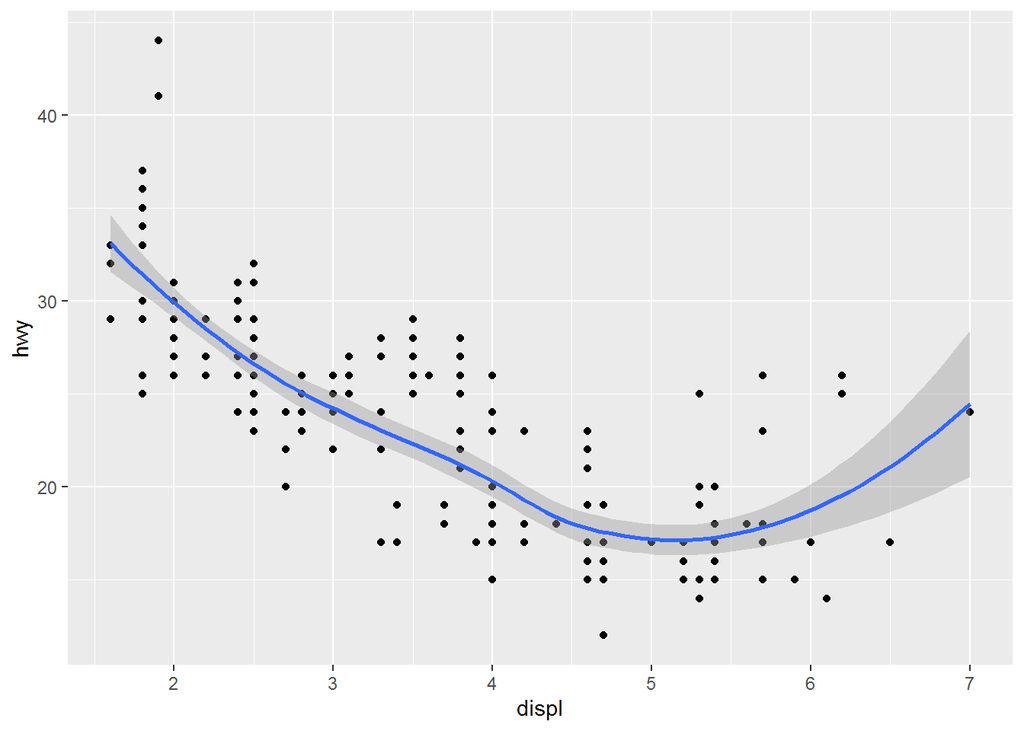

```r
ggplot(data = mpg, mapping = aes(x = displ, y = hwy)) +
  geom_point() +
  geom_smooth()
```

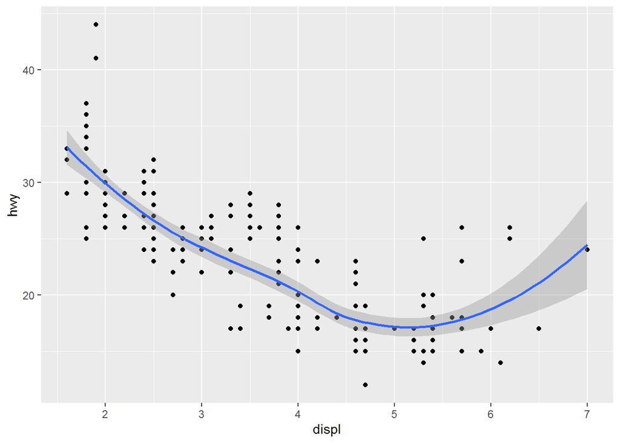

```r
ggplot() +
  geom_point(data = mpg, mapping = aes(x = displ, y = hwy)) +
  geom_smooth(data = mpg, mapping = aes(x = displ, y = hwy))
```

It looks the same since these are just two ways of writing codes. The first one was just putting the aes behind ggplot, then below just by default apply those mappings to each geom in the graph. The coding after ggplot is the “global mappings”, you could extend or overwrite by wrting in the bracket after each geom function.

They do not look different. I am incredibly surprised.

# Open Response

For this exercise, use the **diamonds** dataset in the tidyverse. Use `?diamonds` to get more information about the dataset.

## Step 1: Select 1 numeric variable and 2 categorical variables. Create a graphic using `geom_boxplot()` and `facet_wrap` to illustrate the empirical distributions of the sample.

```r
?diamonds
```

```
## starting httpd help server ... done
```

```r
?boxplot
?geom_area
```

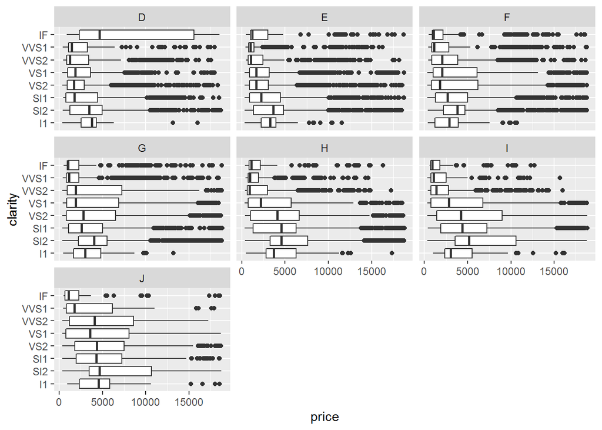

```r
ggplot(data=diamonds, aes(price, clarity))+
geom_boxplot()+facet_wrap(~color)
```

## Step 2: Choose 2 numeric variables and 2 categorical variables and creatively illustrate the relationship between all the variables.

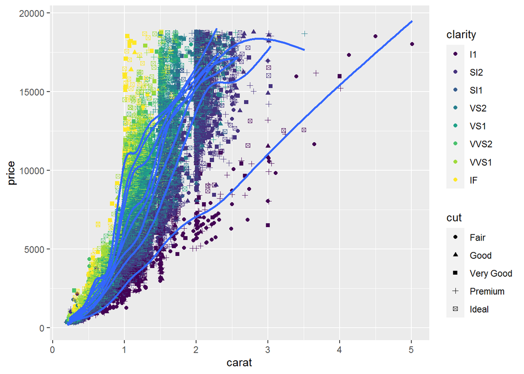

```r
ggplot(data=diamonds,aes(carat,price))+
  geom_point(aes(color=clarity,shape=cut))+
  geom_smooth(aes(group=clarity), se=FALSE)
```

Four variables in one chart is somewhat messy. But as I set price and carat as x and y, the linear increasing curve generated, indicating price and carat is positively related. And shape of the point is used to represent how well the cut is and the color represents the clarity of the diamond. And an interesting fact is when we look the first chart, it seems the worse the clarity is, the higher the relative price will be, since the median value for “IF” is generally less than any other clarity status. However by the second chart we could find the reason, since very few diamonds with highest clarity(yellow color) have high carat amount but less clarity diamonds would have a larger portion of high carat units. Because more carat tends to bid up the price, so the median value for not-IF diamonds would increase by having more numbers of diamonds with higher carat amount. But by the slope of each line projected on each clarity status, higher clarity tends to have higher price on each carat.